[figure not shown]

# Analyzing IMDb Data for AAA Title Insights

## Project Objective

The goal of this report is to analyze IMDb movie data to provide insights for creating the next AAA movie title. By analyzing historical movie data, user ratings, votes, and trends over time, we aim to uncover key factors that drive movie success. The report focuses on answering the following research questions:

1. What was the highest-rated movie in 2020, and how do we balance ratings and votes?
2. Who was the most popular actor in 2020?
3. What are the trends in user-movie preferences over the years?

## Dataset Description

The dataset used in this analysis consists of movie metadata from IMDb, which includes movie titles, genres, release years, ratings, votes, actors, and runtime. It was supplemented by additional data sources such as MovieLens where necessary.

### Loading datasets

```python
import pandas as pd

df_akas = pd.read_csv('title.akas.tsv', sep='\t')

df_akas.head()
```

|  | titleId | ordering | title | region | language | types | attributes | isOriginalTitle |
| --- | --- | --- | --- | --- | --- | --- | --- | --- |
| 0 | tt0000001 | 1 | Carmencita | \N | \N | original | \N | 1 |
| 1 | tt0000001 | 2 | Carmencita | DE | \N | \N | literal title | 0 |
| 2 | tt0000001 | 3 | Carmencita | US | \N | imdbDisplay | \N | 0 |
| 3 | tt0000001 | 4 | Carmencita - spanyol tánc | HU | \N | imdbDisplay | \N | 0 |
| 4 | tt0000001 | 5 | Καρμενσίτα | GR | \N | imdbDisplay | \N | 0 |

```python
df_principals = pd.read_csv('title.principals.tsv', sep='\t')

df_principals.head()
```

|  | tconst | ordering | nconst | category | job | characters |
| --- | --- | --- | --- | --- | --- | --- |
| 0 | tt0000001 | 1 | nm1588970 | self | \N | ["Self"] |
| 1 | tt0000001 | 2 | nm0005690 | director | \N | \N |
| 2 | tt0000001 | 3 | nm0005690 | producer | producer | \N |
| 3 | tt0000001 | 4 | nm0374658 | cinematographer | director of photography | \N |
| 4 | tt0000002 | 1 | nm0721526 | director | \N | \N |

```python
df_name_basics = pd.read_csv('name.basics.tsv', sep='\t')

df_name_basics.head()
```

|  | nconst | primaryName | birthYear | deathYear | primaryProfession | knownForTitles |
| --- | --- | --- | --- | --- | --- | --- |
| 0 | nm0000001 | Fred Astaire | 1899 | 1987 | actor,miscellaneous,producer | tt0072308,tt0050419,tt0053137,tt0027125 |
| 1 | nm0000002 | Lauren Bacall | 1924 | 2014 | actress,soundtrack,archive_footage | tt0037382,tt0075213,tt0117057,tt0038355 |
| 2 | nm0000003 | Brigitte Bardot | 1934 | \N | actress,music_department,producer | tt0057345,tt0049189,tt0056404,tt0054452 |
| 3 | nm0000004 | John Belushi | 1949 | 1982 | actor,writer,music_department | tt0072562,tt0077975,tt0080455,tt0078723 |
| 4 | nm0000005 | Ingmar Bergman | 1918 | 2007 | writer,director,actor | tt0050986,tt0083922,tt0050976,tt0069467 |

```python
df_title_basics = pd.read_csv('title.basics.tsv', sep='\t')

df_title_basics.head()
```

|  | tconst | titleType | primaryTitle | originalTitle | isAdult | startYear | endYear | runtimeMinutes | genres |
| --- | --- | --- | --- | --- | --- | --- | --- | --- | --- |
| 0 | tt0000001 | short | Carmencita | Carmencita | 0 | 1894 | \N | 1 | Documentary,Short |
| 1 | tt0000002 | short | Le clown et ses chiens | Le clown et ses chiens | 0 | 1892 | \N | 5 | Animation,Short |
| 2 | tt0000003 | short | Pauvre Pierrot | Pauvre Pierrot | 0 | 1892 | \N | 5 | Animation,Comedy,Romance |
| 3 | tt0000004 | short | Un bon bock | Un bon bock | 0 | 1892 | \N | 12 | Animation,Short |
| 4 | tt0000005 | short | Blacksmith Scene | Blacksmith Scene | 0 | 1893 | \N | 1 | Comedy,Short |

```python
df_crew = pd.read_csv('title.crew.tsv', sep='\t')

df_crew.head()
```

|  | tconst | directors | writers |
| --- | --- | --- | --- |
| 0 | tt0000001 | nm0005690 | \N |
| 1 | tt0000002 | nm0721526 | \N |
| 2 | tt0000003 | nm0721526 | \N |
| 3 | tt0000004 | nm0721526 | \N |
| 4 | tt0000005 | nm0005690 | \N |

```python
df_episode = pd.read_csv('title.episode.tsv', sep='\t')

df_episode.head()
```

|  | tconst | parentTconst | seasonNumber | episodeNumber |
| --- | --- | --- | --- | --- |
| 0 | tt0031458 | tt32857063 | \N | \N |
| 1 | tt0041951 | tt0041038 | 1 | 9 |
| 2 | tt0042816 | tt0989125 | 1 | 17 |
| 3 | tt0042889 | tt0989125 | \N | \N |
| 4 | tt0043426 | tt0040051 | 3 | 42 |

```python
df_ratings = pd.read_csv('title.ratings.tsv', sep='\t')

df_ratings.head()
```

|  | tconst | averageRating | numVotes |
| --- | --- | --- | --- |
| 0 | tt0000001 | 5.7 | 2088 |
| 1 | tt0000002 | 5.6 | 282 |
| 2 | tt0000003 | 6.5 | 2092 |
| 3 | tt0000004 | 5.4 | 183 |
| 4 | tt0000005 | 6.2 | 2826 |

## 1. Highest Rated Movie in 2020

### Objective:

To identify the highest-rated movie in 2020 using a combination of **average ratings** and **number of votes** to produce a balanced result.

### Methodology:

The IMDb weighted rating formula was used to determine the highest-rated movie of 2020. This formula balances the **average rating (R)** of a movie with the **number of votes (v)** it has received, factoring in a constant **C** (the average rating across all movies) and a minimum threshold **m** (the minimum number of votes required). The formula is as follows:

`WR = (v / (v+m) * R) + (m / (v+m) * C)`

Where:

- **R:** Average rating for the movie.
- **v:** Number of votes for the movie.
- **m:** Minimum votes required to be considered.
- **C:** Mean rating across all movies.

```python
import pandas as pd

# Filter for movies released in 2020
df_2020_movies = df_title_basics[(df_title_basics['startYear'] == '2020') & (df_title_basics['titleType'] == 'movie')]
df_2020_ratings = pd.merge(df_2020_movies, df_ratings, on='tconst')


C = df_ratings['averageRating'].mean()
m = 1000 # minimum votes to be considered

# Calculating weighted rating
df_2020_ratings['weighted_rating'] = df_2020_ratings.apply(
    lambda x: (x['numVotes'] / (x['numVotes'] + m) * x['averageRating']) +
              (m / (x['numVotes'] + m) * C), axis=1)

# Rank movies by weighted rating
highest_rated_2020 = df_2020_ratings[df_2020_ratings['numVotes'] > 1000].sort_values(by='weighted_rating', ascending=False)


highest_rated_2020[['primaryTitle', 'weighted_rating', 'averageRating', 'numVotes']].head()
```

|  | primaryTitle | weighted_rating | averageRating | numVotes |
| --- | --- | --- | --- | --- |
| 149 | Soorarai Pottru | 8.686253 | 8.7 | 125499 |
| 5997 | Demon Slayer: Kimetsu no Yaiba - Mt. Natagumo Arc | 8.601965 | 8.7 | 16738 |
| 2028 | Chal Mera Putt 2 | 8.388788 | 8.8 | 3472 |
| 7625 | Dil Bechara | 8.290185 | 8.3 | 135416 |
| 3189 | Attack on Titan: Chronicle | 8.289031 | 8.4 | 11967 |

### Results:

The movie with the highest weighted rating in 2020 was **Soorarai Pottru**, with a weighted rating of **8.686253**.

## 2. Most Popular Actor in 2020

### Objective:

To identify the most popular actor in 2020 based on a combination of the **number of votes** and **average ratings** of their movies.

### Methodology:

- **Total votes:** received by all movies in which the actor was a lead.
- **Average rating:** across those movies.

By combining both engagement (votes) and quality perception (ratings), the actor with the highest score was identified as the most popular.

```python
import pandas as pd

# Filter for movies released in 2020
df_2020_movies = df_title_basics[(df_title_basics['startYear'] == '2020') & (df_title_basics['titleType'] == 'movie')]
df_2020_ratings = pd.merge(df_2020_movies, df_ratings, on='tconst')

# Filter to include only lead actors (category == 'actor' or 'actress') and low 'ordering' value
df_lead_actors = df_principals[((df_principals['category'] == 'actor') | (df_principals['category'] == 'actress')) & (df_principals['ordering'] <= 2)]
df_2020_lead_actors = pd.merge(df_2020_ratings, df_lead_actors, on='tconst')

# Group by actor and sum the number of votes for movies they appeared in
actor_popularity = df_2020_lead_actors.groupby('nconst').agg(
    total_votes=pd.NamedAgg(column='numVotes', aggfunc='sum'),
    average_rating=pd.NamedAgg(column='averageRating', aggfunc='mean'),
    number_of_movies=pd.NamedAgg(column='tconst', aggfunc='count')
).reset_index()

# Calculate popularity score
actor_popularity['popularity_score'] = actor_popularity['total_votes'] * 0.7 + actor_popularity['average_rating'] * 0.3

# Rank actors based on popularity
most_popular_actor_2020 = actor_popularity.sort_values(by='popularity_score', ascending=False)

most_popular_actor_2020 = pd.merge(most_popular_actor_2020, df_name_basics[['nconst', 'primaryName']], on='nconst')
most_popular_actor_2020[['primaryName', 'popularity_score', 'total_votes', 'average_rating', 'number_of_movies']].head()
```

|  | primaryName | popularity_score | total_votes | average_rating | number_of_movies |
| --- | --- | --- | --- | --- | --- |
| 0 | Robert Pattinson | 424932.290 | 607043 | 7.30 | 1 |
| 1 | John David Washington | 424932.290 | 607043 | 7.30 | 1 |
| 2 | Jamie Foxx | 343191.100 | 490270 | 7.00 | 2 |
| 3 | Tina Fey | 273803.900 | 391145 | 8.00 | 1 |
| 4 | Tom Holland | 231119.075 | 330167 | 7.25 | 2 |

### Results:

The most popular actor in 2020 were **Robert Pattinson and John David Washington**, with a popularity score of **424,932.290**.

## 3. Trends in User-Movie Preferences Over the Years

This section explores trends in user preferences for movies based on data from IMDb, looking into key metrics such as average movie ratings, number of votes (engagement), movie releases over time, genre popularity, and runtime. Each of these factors is analyzed to uncover insights into how user preferences and movie characteristics have evolved over time.

### 3.1 Average Ratings Over Time

#### Objective:

To understand how user movie ratings have changed over the years and whether any significant trends can be identified.

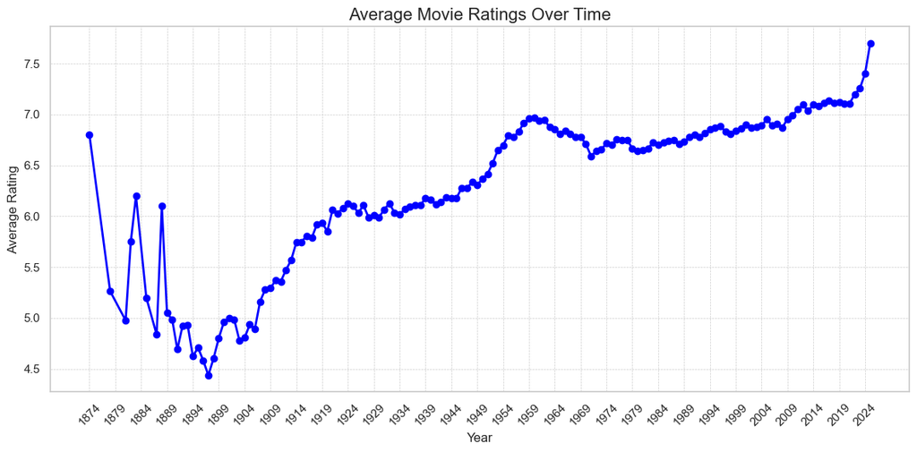

```python
import matplotlib.pyplot as plt
import seaborn as sns
import pandas as pd
import numpy as np

sns.set(style="whitegrid")


ratings_over_time = df_title_basics.merge(df_ratings, on='tconst')

ratings_over_time['startYear'] = pd.to_numeric(ratings_over_time['startYear'], errors='coerce')
ratings_over_time = ratings_over_time.dropna(subset=['startYear'])
ratings_over_time['startYear'] = ratings_over_time['startYear'].astype(int)

# Group by start year and calculate the average rating
ratings_over_time = ratings_over_time.groupby('startYear')['averageRating'].mean().reset_index()


plt.figure(figsize=(12, 6))
plt.plot(ratings_over_time['startYear'], ratings_over_time['averageRating'], marker='o', color='blue', linewidth=2)
plt.xticks(ticks=range(ratings_over_time['startYear'].min(), ratings_over_time['startYear'].max()+1, 5), rotation=45)


plt.title('Average Movie Ratings Over Time', fontsize=16)
plt.xlabel('Year', fontsize=12)
plt.ylabel('Average Rating', fontsize=12)

plt.grid(True, which='both', linestyle='--', linewidth=0.5)
plt.tight_layout()

plt.show()
```

#### Results:

The graph "Average Movie Ratings Over Time" shows that user ratings for movies have seen significant fluctuations since the early years of cinema, with noticeable declines during the late 19th century and early 20th century. However, there is a clear upward trend from the mid-1920s to the present day, with average ratings stabilizing around the 6.5–7.0 range. The increase in ratings in recent years may be attributed to better movie production techniques, improved accessibility, and user engagement via online platforms.

**Interpretation:** As movie production techniques and storytelling have evolved, user satisfaction (as represented by ratings) has generally improved, indicating increased viewer expectations being met.

### 3.2 Average Ratings vs Number of Movies Over Time

#### Objective:

To assess whether the increase in the number of movies produced correlates with changes in average movie ratings over time.

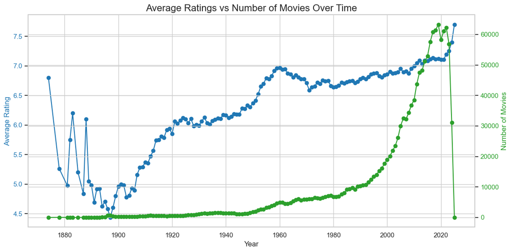

```python
movie_data = df_title_basics.merge(df_ratings, on='tconst')

movie_data['startYear'] = pd.to_numeric(movie_data['startYear'], errors='coerce')
movie_data = movie_data.dropna(subset=['startYear', 'averageRating', 'numVotes'])
movie_data['startYear'] = movie_data['startYear'].astype(int)

# Group by startYear and calculate the average rating and number of movies
ratings_movies_over_time = movie_data.groupby('startYear').agg({
    'averageRating': 'mean',
    'tconst': 'count'  # 'tconst' will give the number of movies
}).reset_index()


fig, ax1 = plt.subplots(figsize=(12, 6))
ax1.set_xlabel('Year', fontsize=12)
ax1.set_ylabel('Average Rating', color='tab:blue', fontsize=12)
ax1.plot(ratings_movies_over_time['startYear'], ratings_movies_over_time['averageRating'], color='tab:blue', marker='o', label='Average Rating')
ax1.tick_params(axis='y', labelcolor='tab:blue')

ax2 = ax1.twinx()
ax2.set_ylabel('Number of Movies', color='tab:green', fontsize=12)
ax2.plot(ratings_movies_over_time['startYear'], ratings_movies_over_time['tconst'], color='tab:green', marker='o', label='Number of Movies')
ax2.tick_params(axis='y', labelcolor='tab:green')

plt.title('Average Ratings vs Number of Movies Over Time', fontsize=16)
fig.tight_layout()
plt.grid(True)
plt.show()
```

#### Results:

The graph "Average Ratings vs Number of Movies Over Time" indicates that while the number of movies produced each year has increased exponentially, especially in the 21st century, the average rating has remained relatively stable. The trend suggests that despite the increasing volume of movies, the quality (as perceived by user ratings) has remained consistently high. This could be due to users finding a more extensive selection of quality movies despite the overall volume increase.

**Interpretation:** Although more movies are being produced every year, this growth in quantity hasn't led to a decline in quality, as indicated by stable user ratings.

### 3.3 User Engagement (Total Votes) Over Time

#### Objective:

To analyze trends in user engagement by looking at the total number of votes movies receive over the years.

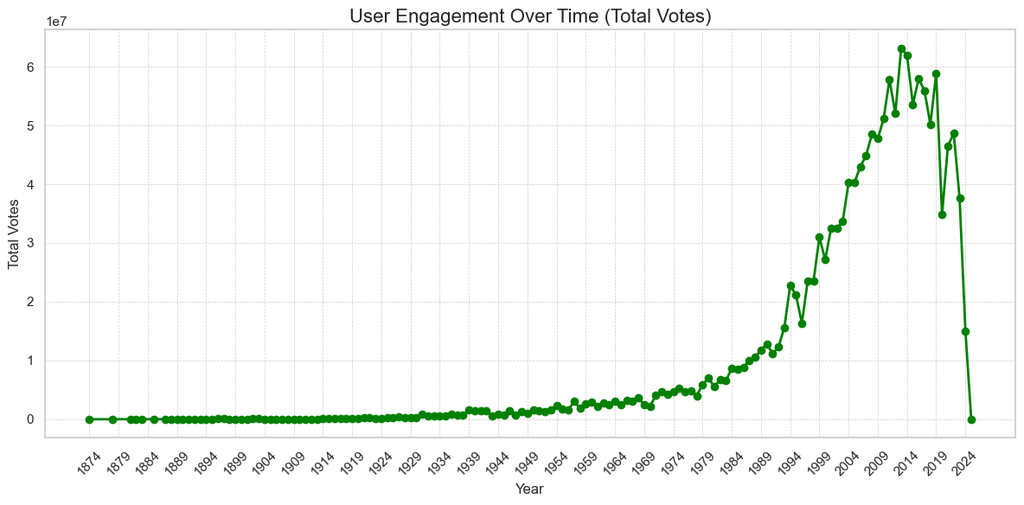

```python
votes_over_time = df_title_basics.merge(df_ratings, on='tconst')

votes_over_time['startYear'] = pd.to_numeric(votes_over_time['startYear'], errors='coerce')
votes_over_time = votes_over_time.dropna(subset=['startYear'])
votes_over_time['startYear'] = votes_over_time['startYear'].astype(int)

# Group by start year and sum the votes
votes_over_time = votes_over_time.groupby('startYear')['numVotes'].sum().reset_index()

plt.figure(figsize=(12, 6))
plt.plot(votes_over_time['startYear'], votes_over_time['numVotes'], marker='o', color='green', linewidth=2)
plt.title('User Engagement Over Time (Total Votes)', fontsize=16)
plt.xlabel('Year', fontsize=12)
plt.ylabel('Total Votes', fontsize=12)
plt.xticks(ticks=range(votes_over_time['startYear'].min(), votes_over_time['startYear'].max()+1, 5), rotation=45)
plt.grid(True, which='both', linestyle='--', linewidth=0.5)
plt.tight_layout()
plt.show()
```

#### Results:

The graph "User Engagement Over Time (Total Votes)" shows a sharp increase in total votes since the late 1990s. This trend aligns with the rise of the internet and online movie platforms, which made it easier for viewers to watch movies and rate them. The spike in engagement in the 2000s indicates the growth of online communities and user participation in rating movies.

**Interpretation:** The rise in total votes correlates with the increasing accessibility of movies through digital platforms and the growing importance of user-driven engagement in determining movie success.

### 3.4 Average Ratings vs Total Votes Over Time

#### Objective:

To determine the relationship between average user ratings and total votes over time, assessing how user engagement affects perceptions of movie quality.

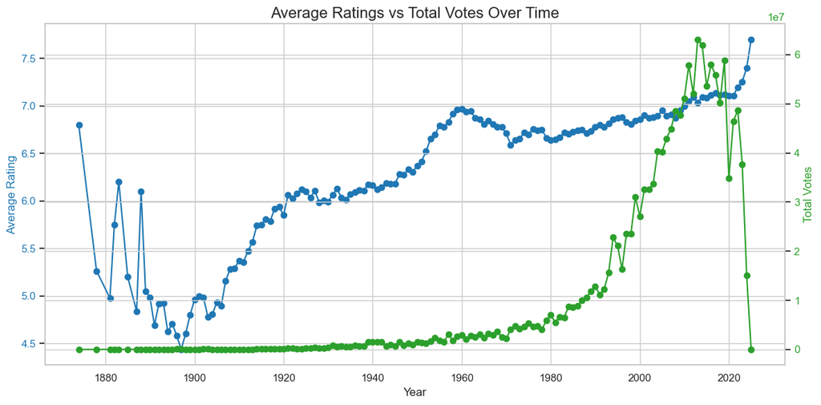

```python
movie_data = df_title_basics.merge(df_ratings, on='tconst')

movie_data['startYear'] = pd.to_numeric(movie_data['startYear'], errors='coerce')
movie_data = movie_data.dropna(subset=['startYear', 'averageRating', 'numVotes'])
movie_data['startYear'] = movie_data['startYear'].astype(int)

# Group by startYear and calculate the average rating and total votes
metrics_over_time = movie_data.groupby('startYear').agg({
    'averageRating': 'mean',
    'numVotes': 'sum'
}).reset_index()

fig, ax1 = plt.subplots(figsize=(12, 6))


ax1.set_xlabel('Year', fontsize=12)
ax1.set_ylabel('Average Rating', color='tab:blue', fontsize=12)
ax1.plot(metrics_over_time['startYear'], metrics_over_time['averageRating'], color='tab:blue', marker='o', label='Average Rating')
ax1.tick_params(axis='y', labelcolor='tab:blue')

ax2 = ax1.twinx()
ax2.set_ylabel('Total Votes', color='tab:green', fontsize=12)
ax2.plot(metrics_over_time['startYear'], metrics_over_time['numVotes'], color='tab:green', marker='o', label='Total Votes')
ax2.tick_params(axis='y', labelcolor='tab:green')

plt.title('Average Ratings vs Total Votes Over Time', fontsize=16)
fig.tight_layout()
plt.grid(True)
plt.show()
```

The graph "Average Ratings vs Total Votes Over Time" illustrates that even as total votes have dramatically increased in recent decades, average movie ratings have remained relatively stable. This suggests that higher engagement doesn't necessarily equate to higher or lower ratings but may reflect broader audience participation.

**Interpretation:** The consistency of ratings despite increasing user engagement implies that a diverse user base is contributing to ratings, but their opinions on movie quality remain balanced.

### 3.5 Average Movie Runtime Over Time

#### Objective:

To examine how the length of movies has evolved and whether this has impacted user ratings.

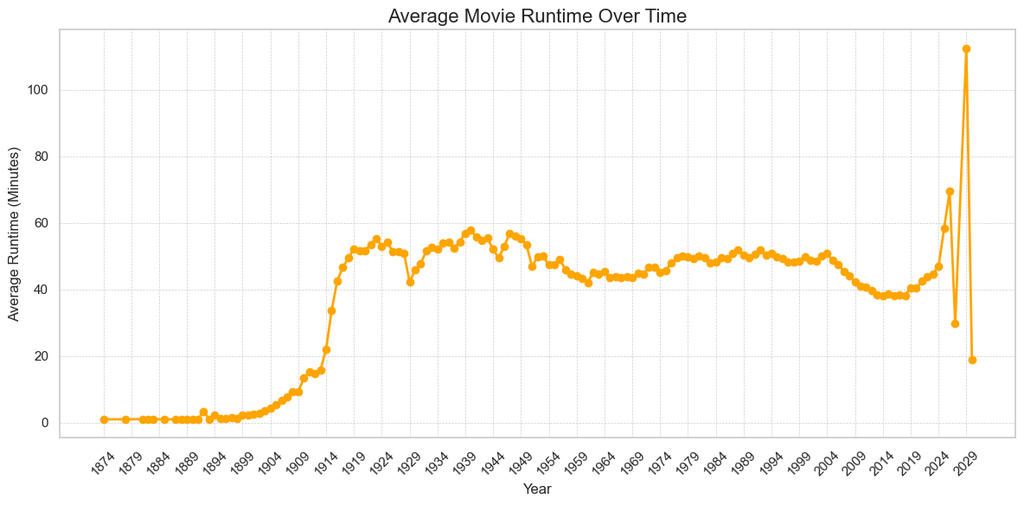

```python
df_title_basics['startYear'] = pd.to_numeric(df_title_basics['startYear'], errors='coerce')
df_title_basics['runtimeMinutes'] = pd.to_numeric(df_title_basics['runtimeMinutes'], errors='coerce')

runtime_over_time = df_title_basics.dropna(subset=['startYear', 'runtimeMinutes'])
runtime_over_time['startYear'] = runtime_over_time['startYear'].astype(int)
runtime_over_time = runtime_over_time.groupby('startYear')['runtimeMinutes'].mean().reset_index()

plt.figure(figsize=(12, 6))
plt.plot(runtime_over_time['startYear'], runtime_over_time['runtimeMinutes'], marker='o', color='orange', linewidth=2)
plt.title('Average Movie Runtime Over Time', fontsize=16)
plt.xlabel('Year', fontsize=12)
plt.ylabel('Average Runtime (Minutes)', fontsize=12)
plt.xticks(ticks=range(runtime_over_time['startYear'].min(), runtime_over_time['startYear'].max()+1, 5), rotation=45)
plt.grid(True, which='both', linestyle='--', linewidth=0.5)
plt.tight_layout()
plt.show()
```

#### Results:

The "Average Movie Runtime Over Time" graph shows a gradual increase in movie runtimes throughout the 20th century, with a peak in the 1930s and 1940s, followed by a stabilization in the following decades. There is a notable increase in runtimes in recent years, possibly due to changes in storytelling and production techniques.

**Interpretation:** Movies are becoming longer in recent years, possibly due to the complexity of modern narratives and the desire to provide more comprehensive stories, especially in franchises and epics.

### 3.6 Average Rating by Movie Runtime

#### Objective:

To investigate whether movie runtime has an impact on user ratings.

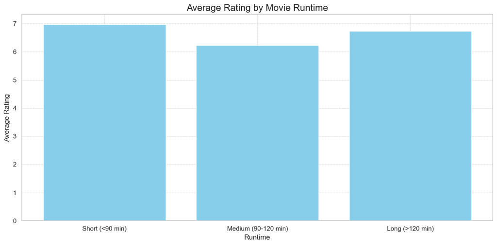

```python
df_title_basics['runtimeMinutes'] = pd.to_numeric(df_title_basics['runtimeMinutes'], errors='coerce')
movie_data = df_title_basics.merge(df_ratings, on='tconst')
movie_data = movie_data.dropna(subset=['runtimeMinutes', 'averageRating'])

# Create runtime bins (e.g., Short: <90 min, Medium: 90-120 min, Long: >120 min)
bins = [0, 90, 120, np.inf]
labels = ['Short (<90 min)', 'Medium (90-120 min)', 'Long (>120 min)']
movie_data['runtime_bin'] = pd.cut(movie_data['runtimeMinutes'], bins=bins, labels=labels, include_lowest=True)

runtime_ratings = movie_data.groupby('runtime_bin')['averageRating'].mean().reset_index()

plt.figure(figsize=(12, 6))
plt.bar(runtime_ratings['runtime_bin'], runtime_ratings['averageRating'], color='skyblue')
plt.title('Average Rating by Movie Runtime', fontsize=16)
plt.xlabel('Runtime', fontsize=12)
plt.ylabel('Average Rating', fontsize=12)
plt.grid(True, linestyle='--', linewidth=0.5)
plt.tight_layout()
plt.show()
```

## Results:

The "Average Rating by Movie Runtime" graph categorizes movies into three bins based on runtime: short (<90 min), medium (90-120 min), and long (>120 min). The analysis shows that short-length movies (<90 min) receive the highest average ratings, followed closely by long and medium-length movies, which tend to receive slightly lower ratings.

## Interpretation:

Shorter films (<90 min) may receive higher ratings because they cater to a niche audience that appreciates concise, focused storytelling. These films might benefit from a tight narrative that minimizes filler content and maintains viewer engagement. Additionally, the audience’s expectations for short films may differ, with viewers possibly valuing the ability to deliver a satisfying experience in a shorter time frame. These factors contribute to the higher average ratings observed for short-length movies.

### 3.7 Genre Popularity Over Time (by Votes)

#### Objective:

To explore how the popularity of different movie genres has evolved over time, as measured by user votes.

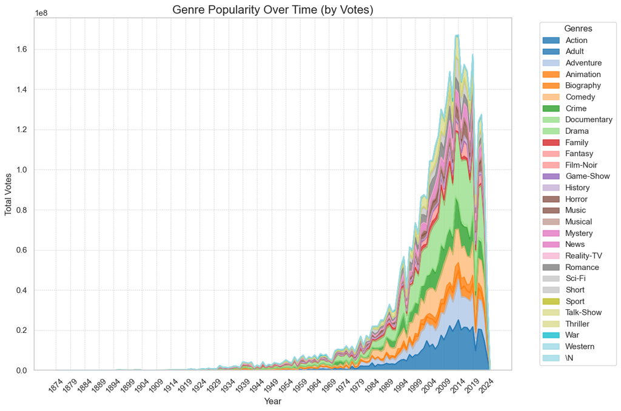

```python
# Separate multiple genres into individual rows
df_title_basics['genres'] = df_title_basics['genres'].str.split(',')
df_title_basics_exploded = df_title_basics.explode('genres')

genre_popularity = df_title_basics_exploded.merge(df_ratings, on='tconst')

genre_popularity['startYear'] = pd.to_numeric(genre_popularity['startYear'], errors='coerce')
genre_popularity = genre_popularity.dropna(subset=['startYear'])
genre_popularity['startYear'] = genre_popularity['startYear'].astype(int)
genre_popularity = genre_popularity.groupby(['startYear', 'genres'])['numVotes'].sum().unstack().fillna(0)

plt.figure(figsize=(12, 8))
genre_popularity.plot(kind='area', stacked=True, figsize=(12, 8), colormap='tab20', alpha=0.8)
plt.title('Genre Popularity Over Time (by Votes)', fontsize=16)
plt.xlabel('Year', fontsize=12)
plt.ylabel('Total Votes', fontsize=12)
plt.xticks(ticks=range(genre_popularity.index.min(), genre_popularity.index.max()+1, 5), rotation=45)
plt.legend(title="Genres", bbox_to_anchor=(1.05, 1), loc='upper left')
plt.grid(True, which='both', linestyle='--', linewidth=0.5)
plt.tight_layout()
plt.show()
```

### 3.8 Lead Actor Age and Success

**Objective:**

To investigate the relationship between the lead actor's age and movie success, measured by both average ratings and votes. This analysis aims to explore whether specific age groups of lead actors are correlated with higher movie ratings or increased user engagement (votes).

```python
df_movies = df_title_basics.merge(df_ratings, on='tconst')

df_movies['startYear'] = pd.to_numeric(df_movies['startYear'], errors='coerce')
df_movies = df_movies.dropna(subset=['startYear', 'averageRating', 'numVotes'])
df_movies['startYear'] = df_movies['startYear'].astype(int)
```

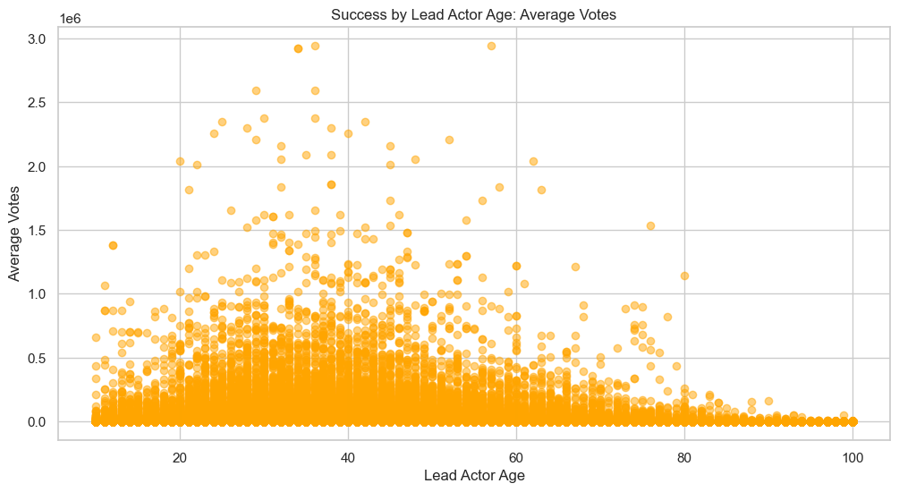

```python
# Get only lead actors
df_principals['role'] = df_principals['ordering'].apply(lambda x: 'Lead' if x in [1, 2] else 'Supporting')

df_lead_actors = df_principals[df_principals['role'] == 'Lead'].merge(df_name_basics[['nconst', 'birthYear']], on='nconst')
df_lead_actors['birthYear'] = pd.to_numeric(df_lead_actors['birthYear'], errors='coerce')
df_lead_actors = df_lead_actors.dropna(subset=['birthYear'])
df_movies_lead_actors = df_movies.merge(df_lead_actors[['tconst', 'nconst', 'birthYear']], on='tconst')
df_movies_lead_actors['actor_age'] = df_movies_lead_actors['startYear'] - df_movies_lead_actors['birthYear']
df_movies_lead_actors_filtered = df_movies_lead_actors[df_movies_lead_actors['actor_age'].between(10, 100)]

plt.figure(figsize=(12, 6))
plt.scatter(df_movies_lead_actors_filtered['actor_age'], df_movies_lead_actors_filtered['numVotes'], color='orange', alpha=0.5)
plt.xlabel('Lead Actor Age')
plt.ylabel('Average Votes')
plt.title('Success by Lead Actor Age: Average Votes')
plt.grid(True)
plt.show()
```

### 3.9 Success by Language

**Objective:**

To examine how the primary language of a movie impacts its success, measured by average ratings and votes. This analysis helps determine if movies in specific languages are rated higher or receive more votes.

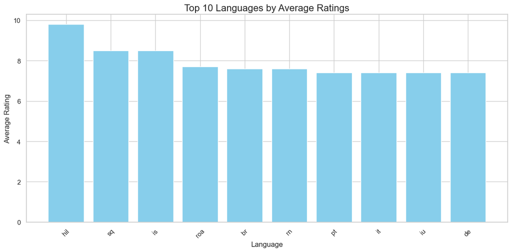

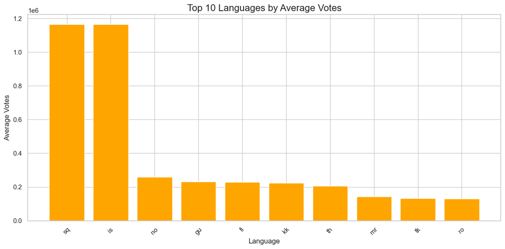

```python
df_movies_akas = df_akas.merge(df_ratings, left_on='titleId', right_on='tconst', how='left')

# Group by language and calculate the average rating and votes
language_success = df_movies_akas.groupby('language').agg({
    'averageRating': 'mean',
    'numVotes': 'mean'
}).reset_index()


language_success_filtered = language_success[language_success['language'] != '\\N']
top_languages_by_rating = language_success_filtered.sort_values(by='averageRating', ascending=False).head(10)

plt.figure(figsize=(12, 6))
plt.bar(top_languages_by_rating['language'], top_languages_by_rating['averageRating'], color='skyblue')
plt.xlabel('Language', fontsize=12)
plt.ylabel('Average Rating', fontsize=12)
plt.title('Top 10 Languages by Average Ratings', fontsize=16)
plt.xticks(rotation=45)
plt.tight_layout()
plt.show()

top_languages_by_votes = language_success_filtered.sort_values(by='numVotes', ascending=False).head(10)

plt.figure(figsize=(12, 6))
plt.bar(top_languages_by_votes['language'], top_languages_by_votes['numVotes'], color='orange')
plt.xlabel('Language', fontsize=12)
plt.ylabel('Average Votes', fontsize=12)
plt.title('Top 10 Languages by Average Votes', fontsize=16)
plt.xticks(rotation=45)
plt.tight_layout()
plt.show()
```

#### Results:

- **Average Ratings:** Movies in certain languages (e.g., Hiligaynon and Albanian) receive high average ratings, though this could be attributed to a smaller sample size. Further analysis is required to confirm this.  
- **Average Votes:** Languages like Albanian ('sq') and Icelandic ('is') attract a significantly larger number of votes, suggesting higher user engagement for movies in these languages.

### 3.10 Success by Region

**Objective:**

To explore how the region associated with a movie influences its success, as measured by average ratings and votes. This helps identify whether certain geographic regions tend to produce more successful films.

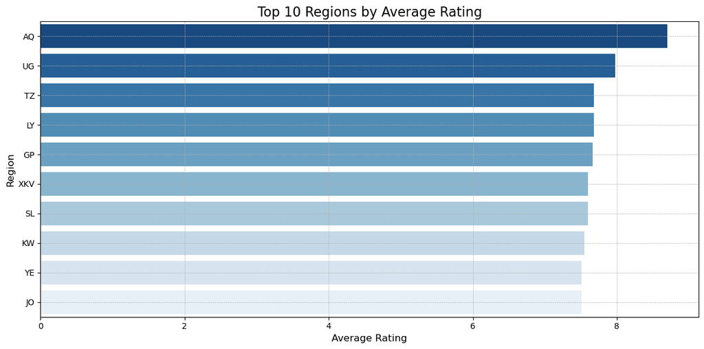

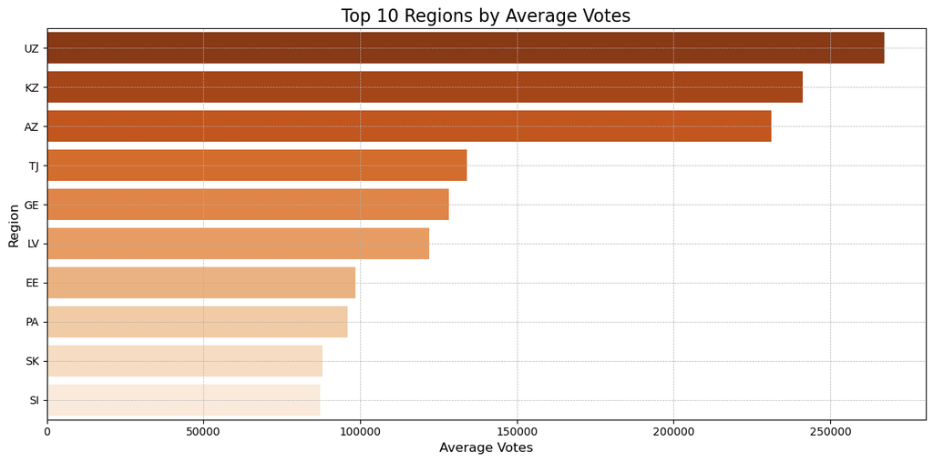

```python
import matplotlib.pyplot as plt
import seaborn as sns
import pandas as pd
import numpy as np

# Merge akas with ratings to include rating and votes data
df_movies_akas_region = df_akas.merge(df_ratings, left_on='titleId', right_on='tconst', how='left')

# Group by region and calculate the average rating and votes
region_success = df_movies_akas_region.groupby('region').agg({
    'averageRating': 'mean',
    'numVotes': 'mean'
}).reset_index()

# Filter out rows where region is NaN or empty
region_success = region_success[region_success['region'].notnull() & (region_success['region'] != '\\N')]

# Sort by average rating and get top 10 regions by average rating
top_10_regions_rating = region_success.sort_values(by='averageRating', ascending=False).head(10)

# Sort by average votes and get top 10 regions by average votes
top_10_regions_votes = region_success.sort_values(by='numVotes', ascending=False).head(10)

# Plot top 10 regions by average rating (Horizontal Bar Graph)
plt.figure(figsize=(12, 6))
sns.barplot(x='averageRating', y='region', data=top_10_regions_rating, palette='Blues_r')
plt.title('Top 10 Regions by Average Rating', fontsize=16)
plt.xlabel('Average Rating', fontsize=12)
plt.ylabel('Region', fontsize=12)
plt.grid(True, which='both', linestyle='--', linewidth=0.5)
plt.tight_layout()
plt.show()

# Plot top 10 regions by average votes (Horizontal Bar Graph)
plt.figure(figsize=(12, 6))
sns.barplot(x='numVotes', y='region', data=top_10_regions_votes, palette='Oranges_r')
plt.title('Top 10 Regions by Average Votes', fontsize=16)
plt.xlabel('Average Votes', fontsize=12)
plt.ylabel('Region', fontsize=12)
plt.grid(True, which='both', linestyle='--', linewidth=0.5)
plt.tight_layout()
plt.show()
```

#### Results:

The bar charts below illustrate the top 10 regions by average rating and average votes. Movies from 'AQ' (Antarctica) and 'UG' (Uganda) top the ratings chart, while regions like 'UZ' (Uzbekistan) and 'KZ' (Kazakhstan) dominate the votes chart.

- **Average Ratings:** Some regions like 'Antarctica' and 'Uganda' stand out with exceptionally high average ratings, although these regions may have fewer movies contributing to the data.  
- **Average Votes:** Regions such as Uzbekistan and Kazakhstan receive the highest number of votes, indicating higher engagement from audiences in these areas.

## 4. Defining a Hit Movie Metric

The goal is to define a metric that captures the notion of a ‘hit movie’ and provide recommendations to a movie studio director looking to invest in building the next AAA title. This metric is based on both the **average rating** and **user votes** from the dataset. The aim is to balance **critical success** (measured by ratings) with **audience engagement** (measured by votes).

The analysis has revealed various factors that impact a movie's rating and audience engagement, such as **lead actor age**, **movie runtime**, **language**, **region**, and **genre popularity**. Based on these results, we propose a metric that combines average ratings and total votes to assess movie success.

The formula for this hit movie metric is as follows:

```
Hit Movie Score = (α × Normalized Average Rating) + (β × Normalized Total Votes)
```

Where:

- α and β are weights that can be adjusted based on whether the studio prioritizes audience engagement (votes) or critical success (ratings).
- Normalized values scale the ratings and votes to comparable ranges.

Based on the results from the previous analysis, we can provide the following recommendations to optimize both ratings and votes for the next AAA title:

### A. Lead Actor Age and Success

**Recommendation:**

Cast lead actors aged between 20-40 years to maximize audience engagement and increase the likelihood of higher votes.

### B. Movie Runtime and Success

**Recommendation:**

Consider shorter runtimes (<90 minutes) for genres like comedy or animation, which thrive with brevity.

### C. Success by Region

Movies from regions such as Uzbekistan and Kazakhstan receive a high number of votes, reflecting strong engagement from audiences in these regions. Regions like Antarctica and Uganda score high average ratings, but likely with smaller sample sizes.

**Recommendation:**

Focus promotional efforts in regions with strong voting trends, like Uzbekistan and Kazakhstan, while ensuring broader global appeal to maximize reach.

### D. Genre Popularity

**Recommendation:**

## 5. Conclusion

In terms of regional success, targeting regions like Uzbekistan and Kazakhstan for promotional efforts is a smart move, as these regions demonstrate strong voting trends. However, it is also important to ensure global reach by focusing on larger, more diverse markets.

By considering these factors—lead actor age, movie runtime, language, regional focus, and genre—a studio director can create a balanced strategy that maximizes both critical success and audience engagement, leading to the production of a hit movie.